# Predicción del Desempleo por Perfil Demográfico en Colombia

## 3.1 Variables por módulo

### 3.1.1 Características generales, seguridad social en salud y educación

| Variable | Descripción |
| --- | --- |
| PERIODO | Periodo de la encuesta |
| MES | Mes de referencia de la encuesta |
| PER | Período de la encuesta |
| DIRECTORIO | Identificador de la encuesta |
| SECUENCIA_P | Secuencia padre |
| ORDEN | Número de orden de la persona en el hogar |
| HOGAR | Identificador del hogar dentro de la vivienda |
| REGIS | Número de registro |
| AREA | Área geográfica (cabecera, centro poblado, rural disperso) |
| CLASE | Clase de área (urbana/rural) |
| FEX_C18 | Factor de expansión de personas de 18 años y más |
| DPTO | Código del departamento |
| PT | Período trimestral |
| P6016 | Número de orden de la persona que proporciona la información |
| P3271 | Sexo al nacer |
| P6040 | Edad en años cumplidos |
| P6030S1 | Mes de nacimiento |
| P6030S3 | Año de nacimiento |
| P6050 | Parentesco con el jefe o jefa del hogar |
| P6083 | Indicador de si la madre reside en el hogar |
| P6083S1 | Número de orden de la madre en el hogar |
| P6081 | Indicador de si el padre reside en el hogar |
| P6081S1 | Número de orden del padre en el hogar |
| P2057 | Autorreconocimiento como campesino(a) |
| P2059 | Si alguna vez se consideró campesino(a) |
| P2061 | Si considera que la comunidad donde vive es campesina |
| P6080 | Pertenencia étnica o autorreconocimiento cultural |
| P6080S1 | Pueblo o etnia indígena a la que pertenece |
| P6080S1A1 | Especificación del pueblo o etnia |
| P6070 | Estado conyugal actual |
| P6071 | Indicador de si el cónyuge reside en el hogar |
| P6071S1 | Número de orden del cónyuge en el hogar |
| P3147S1 | Dificultad por COVID-19: acceso a alimentos |
| P3147S2 | Dificultad por COVID-19: acceso a medicamentos |
| P3147S3 | Dificultad por COVID-19: pago de arriendo o servicios |
| P3147S4 | Dificultad por COVID-19: pérdida de empleo |
| P3147S5 | Dificultad por COVID-19: cierre del negocio |
| P3147S6 | Dificultad por COVID-19: dificultad para estudiar |
| P3147S7 | Dificultad por COVID-19: problemas de salud mental |
| P3147S8 | Dificultad por COVID-19: violencia intrafamiliar |
| P3147S9 | Dificultad por COVID-19: otra dificultad |
| P3147S10 | Dificultad por COVID-19: ninguna |
| P3147S11 | Dificultad por COVID-19: no sabe/no informa |
| P3147S10A1 | Especificación de otra dificultad por COVID-19 |
| P6090 | Afiliación a seguridad social en salud (EPS o ARS) |
| P6100 | Régimen de afiliación en salud (contributivo, subsidiado, especial) |
| P6110 | Quién paga mensualmente la afiliación en salud |
| P6120 | Valor mensual pagado o descontado por afiliación en salud |
| P1906S1 | Dificultad para oír, aún con audífonos |
| P1906S2 | Dificultad para hablar o conversar |
| P1906S3 | Dificultad para ver, aún con lentes |
| P1906S4 | Dificultad para mover el cuerpo, caminar o subir escaleras |
| P1906S5 | Dificultad para agarrar o mover objetos con las manos |
| P1906S6 | Dificultad para entender, aprender, recordar o tomar decisiones |
| P1906S7 | Dificultad para comer, vestirse o bañarse por sí mismo(a) |
| P1906S8 | Dificultad para relacionarse o interactuar con otras personas |
| P6160 | Sabe leer y escribir |
| P6170 | Asistencia actual a una institución educativa |
| P3041 | Tipo de institución educativa a la que asiste (pública/privada) |
| P3042 | Mayor nivel educativo alcanzado y último grado o semestre aprobado |
| P3042S1 | Año o grado del nivel educativo alcanzado |
| P3042S2 | Área o disciplina del nivel educativo alcanzado |
| P3043 | Título o diploma de mayor nivel educativo recibido |
| P3043S1 | Área o disciplina del título recibido |
| P3038 | Atracción sexual o romántica (orientación sexual) |
| P3039 | Identidad de género |
| POB_MAY18 | Indicador de población mayor de 18 años |

### 3.1.2 Datos del hogar y la vivienda

| Variable | Descripción |
| --- | --- |
| PERIODO | Periodo de la encuesta |
| MES | Mes de referencia de la encuesta |
| PER | Período de la encuesta |
| DIRECTORIO | Identificador de la encuesta |
| SECUENCIA_P | Secuencia padre |
| HOGAR | Identificador del hogar dentro de la vivienda |
| REGIS | Número de registro |
| AREA | Área geográfica (cabecera, centro poblado, rural disperso) |
| CLASE | Clase de área (urbana/rural) |
| FEX_C18 | Factor de expansión de personas de 18 años y más |
| DPTO | Código del departamento |
| P4000 | Tipo de vivienda |
| P4010 | Material predominante de las paredes exteriores |
| P4020 | Material predominante de los pisos |
| P4030S1 | Disponibilidad de energía eléctrica |
| P4030S1A1 | Estrato para tarifa de energía eléctrica |
| P4030S2 | Disponibilidad de gas natural conectado a red pública |
| P4030S3 | Disponibilidad de alcantarillado |
| P4030S4 | Disponibilidad de recolección de basuras |
| P4030S4A1 | Frecuencia de recolección de basuras (veces por semana) |
| P4030S5 | Disponibilidad de acueducto |
| P70 | Número de hogares en la vivienda |
| P5000 | Total de cuartos disponibles en el hogar (incluye sala-comedor) |
| P5010 | Cuartos usados para dormir |
| P5020 | Tipo de servicio sanitario que utiliza el hogar |
| P5030 | Uso compartido o exclusivo del servicio sanitario |
| P5040 | Forma principal de eliminación de basuras |
| P5050 | Fuente principal de agua para consumo humano |
| P5070 | Lugar donde se preparan los alimentos |
| P5080 | Energía o combustible principal para cocinar |
| P5090 | Tenencia de la vivienda (propia, arrendada, usufructo, etc.) |
| P5090S1 | Especificación del tipo de tenencia |
| P5100 | Valor mensual de cuota de amortización de crédito hipotecario |
| P5110 | Precio mínimo estimado de venta de la vivienda |
| P5130 | Valor estimado de arriendo mensual si tuviera que pagarlo |
| P5140 | Valor mensual de arriendo pagado actualmente |
| P5222S1 | Uso de cuenta corriente en el hogar |
| P5222S2 | Uso de cuenta de ahorros en el hogar |
| P5222S3 | Uso de CDT en el hogar |
| P5222S4 | Tenencia de préstamo para compra de vivienda |
| P5222S5 | Tenencia de préstamo para compra de vehículo |
| P5222S6 | Tenencia de préstamo de libre inversión |
| P5222S7 | Uso de tarjeta de crédito en el hogar |
| P5222S8 | Uso de otro producto financiero en el hogar |
| P5222S9 | Ningún producto financiero en el hogar |
| P5222S10 | No sabe si tiene productos financieros |
| P5222S8A1 | Especificación del otro producto financiero |
| P6008 | Total de personas en el hogar |

### 3.1.3 Fuerza de trabajo

| Variable | Descripción |
| --- | --- |
| PERIODO | Periodo de la encuesta |
| MES | Mes de referencia de la encuesta |
| PER | Período de la encuesta |
| DIRECTORIO | Identificador de la encuesta |
| SECUENCIA_P | Secuencia padre |
| ORDEN | Número de orden de la persona en el hogar |
| HOGAR | Identificador del hogar dentro de la vivienda |
| REGIS | Número de registro |
| AREA | Área geográfica (cabecera, centro poblado, rural disperso) |
| CLASE | Clase de área (urbana/rural) |
| FEX_C18 | Factor de expansión de personas de 18 años y más |
| DPTO | Código del departamento |
| FT | Indicador de pertenencia a la fuerza de trabajo (ocupado o desocupado) |
| FFT | Indicador de estar fuera de la fuerza de trabajo (inactivo) |
| PET | Indicador de población en edad de trabajar (15 años y más en GEIH 2025) |
| P6240 | Actividad principal realizada la semana pasada |
| P6240S1 | Especificación de la actividad principal de la semana pasada |
| P6240S2 | Si recibió remuneración en dinero o especie por esa actividad |
| P6250 | Si realizó alguna actividad paga por una hora o más la semana pasada |
| P6260 | Si tenía trabajo o negocio generador de ingresos, aunque no haya trabajado la semana pasada |
| P6260S1 | Razón por la que no trabajó la semana pasada (teniendo empleo) |
| P6260S1A1 | Especificación de la razón de ausencia laboral |
| P6260S2 | Tiempo estimado de ausencia del trabajo |
| P6270 | Si trabajó sin remuneración en empresa o negocio familiar la semana pasada |
| P6280 | Si hizo diligencias para buscar trabajo o instalar negocio en las últimas 4 semanas |
| P6290 | Actividad principal para conseguir empleo en las últimas 4 semanas |
| P3362S1 | Buscó empleo pidiendo ayuda a familiares o amigos |
| P3362S2 | Buscó empleo visitando empresas o enviando hojas de vida |
| P3362S3 | Usó agencias de empleo, SENA o Servicio Público de Empleo |
| P3362S4 | Buscó empleo por avisos clasificados |
| P3362S5 | Buscó empleo presentándose a convocatorias |
| P3362S6 | Hizo preparativos para iniciar un negocio |
| P3362S7 | Buscó empleo por otro medio |
| P3362S8 | No sabe/no informa cómo buscó empleo |
| P3362S7A1 | Especificación del otro medio de búsqueda de empleo |
| P6300 | Si desea conseguir un trabajo remunerado o instalar un negocio |
| P6310 | Razón principal por la que no buscó empleo aunque desea trabajar |
| P6310S1 | Especificación de la razón de no búsqueda |
| P6320 | Si trabajó al menos 2 semanas consecutivas en los últimos 12 meses |
| P6330 | Si ha hecho diligencias para buscar trabajo después de su último empleo |
| P6340 | Si ha buscado trabajo o negocio en los últimos 12 meses |
| P6350 | Meses transcurridos desde que dejó de buscar trabajo por última vez |
| P6351 | Si estaba disponible para trabajar la semana pasada si le hubiera resultado empleo |

### 3.1.4 Migración

| Variable | Descripción |
| --- | --- |
| PERIODO | Periodo de la encuesta |
| MES | Mes de referencia de la encuesta |
| PER | Período de la encuesta |
| DIRECTORIO | Identificador de la encuesta |
| SECUENCIA_P | Secuencia padre |
| ORDEN | Número de orden de la persona en el hogar |
| HOGAR | Identificador del hogar dentro de la vivienda |
| REGIS | Número de registro |
| AREA | Área geográfica (cabecera, centro poblado, rural disperso) |
| CLASE | Clase de área (urbana/rural) |
| FEX_C18 | Factor de expansión de personas de 18 años y más |
| DPTO | Código del departamento |
| P3373 | País o región de nacimiento |
| P3373S1 | Departamento de nacimiento |
| P3373S2 | Municipio de nacimiento |
| P3373S3 | País extranjero de nacimiento |
| P3373S3A1 | Año de llegada a Colombia por última vez |
| P3373S3A2 | Mes de llegada a Colombia por última vez |
| P3374 | Nacionalidad |
| P3374S1 | Municipio de residencia hace 5 años |
| P3374S2 | Departamento de residencia hace 5 años |
| P3374S3 | País de residencia hace 5 años (si era en el exterior) |
| P3375S1 | Tiempo de intención de quedarse en Colombia (meses) |
| P3376 | Si alguna vez vivió en otro(s) país(es) por más de 6 meses |
| P3377 | Si trabajó mientras estuvo viviendo en el exterior |
| P3378 | País al que viajó por última vez a trabajar |
| P3378S1 | Duración del trabajo en ese país (meses) |
| P3379 | Año en que viajó a ese país a trabajar |
| P3380 | Año en que salió de ese país |
| P3381 | Año en que volvió a vivir en Colombia |
| P3382 | Lugar de residencia hace 5 años |
| P3382S1 | Departamento de residencia hace 5 años |
| P3382S2 | Municipio de residencia hace 5 años |
| P3382S3 | País extranjero de residencia hace 5 años |
| P3383 | Tipo de lugar de residencia hace 5 años (urbano/rural) |
| P3384 | Lugar de residencia hace 12 meses |
| P3384S1 | Departamento de residencia hace 12 meses |
| P3384S2 | Municipio de residencia hace 12 meses |
| P3384S3 | País extranjero de residencia hace 12 meses |
| P3385 | Tipo de lugar de residencia hace 12 meses (urbano/rural) |
| P3386 | Motivo principal del cambio de residencia en los últimos 12 meses |
| P3386S1 | Especificación del motivo de cambio de residencia |
| P3375 | Si tiene intención de quedarse a vivir en Colombia |

### 3.1.5 No ocupados

| Variable | Descripción |
| --- | --- |
| PERIODO | Periodo de la encuesta |
| MES | Mes de referencia de la encuesta |
| PER | Período de la encuesta |
| DIRECTORIO | Identificador de la encuesta |
| SECUENCIA_P | Secuencia padre |
| ORDEN | Número de orden de la persona en el hogar |
| HOGAR | Identificador del hogar dentro de la vivienda |
| REGIS | Número de registro |
| AREA | Área geográfica (cabecera, centro poblado, rural disperso) |
| CLASE | Clase de área (urbana/rural) |
| FEX_C18 | Factor de expansión de personas de 18 años y más |
| DPTO | Código del departamento |
| FFT | Indicador de estar fuera de la fuerza de trabajo (inactivo) |
| DSCY | Indicador de desocupado con experiencia laboral previa |
| DSI | Indicador de desocupado sin experiencia laboral |
| P7250 | Semanas buscando trabajo (desocupado) |
| P7280 | Si ha buscado trabajo como asalariado, independiente o cualquiera |
| P744 | Disponibilidad para trabajar la semana pasada si hubiera resultado empleo |
| P3074 | Disponibilidad futura para trabajar si resultara un empleo |
| P7260 | Horas a la semana disponibles para trabajar |
| P1806 | Salario mínimo mensual aceptable para aceptar un empleo (salario de reserva) |
| P7430 | Si ha trabajado alguna vez al menos dos semanas consecutivas |
| P7440S1 | Meses desde que trabajó por última vez |
| P7440S2 | Semanas desde que trabajó por última vez |
| P7450 | Motivo principal por el que dejó su último trabajo |
| P7350 | Posición ocupacional en el último trabajo |
| P7360 | Actividad económica del último trabajo |
| P9460 | Si recibe actualmente subsidio de desempleo |
| P1519 | Si cotiza actualmente a un fondo de pensiones |
| P1883 | Fondo de pensiones al que cotiza actualmente |
| P7422 | Si recibió ingresos por concepto de trabajo el mes pasado |
| P7422S1 | Valor de los ingresos laborales recibidos el mes pasado |
| OFICIO1_C8 | Oficio principal del último empleo clasificado (CIUO-08) |
| OFICIO2_C8 | Oficio secundario del último empleo clasificado (CIUO-08) |
| RAMA2D_D_R4 | Rama de actividad del último empleo a 2 dígitos (CIIU Rev.4) |
| RAMA4D_D_R4 | Rama de actividad del último empleo a 4 dígitos (CIIU Rev.4) |
| P7440 | Tiempo transcurrido desde que trabajó por última vez (codificado) |

### 3.1.6 Ocupados

| Variable | Descripción |
| --- | --- |
| PERIODO | Periodo de la encuesta |
| MES | Mes de referencia de la encuesta |
| PER | Período de la encuesta |
| DIRECTORIO | Identificador de la encuesta |
| SECUENCIA_P | Secuencia padre |
| ORDEN | Número de orden de la persona en el hogar |
| HOGAR | Identificador del hogar dentro de la vivienda |
| REGIS | Número de registro |
| AREA | Área geográfica (cabecera, centro poblado, rural disperso) |
| CLASE | Clase de área (urbana/rural) |
| FEX_C18 | Factor de expansión de personas de 18 años y más |
| DPTO | Código del departamento |
| FT | Indicador de pertenencia a la fuerza de trabajo |
| P3044S2 | Rama de actividad económica del empleo principal |
| P6440 | Si tiene algún tipo de contrato (verbal o escrito) |
| P6450 | Tipo de contrato: verbal o escrito |
| P6460 | Contrato a término indefinido o a término fijo |
| P6460S1 | Duración del contrato a término fijo (meses) |
| P6400 | Si la empresa contratante es la misma donde trabaja |
| P6410 | Tipo de empresa que contrató al trabajador |
| P6422 | Conformidad con el tipo de contrato |
| P6420S2 | Rama de actividad de la empresa contratante |
| P6424S1 | Derecho a prima de servicios por contrato actual |
| P6424S2 | Derecho a vacaciones pagadas por contrato actual |
| P6424S3 | Derecho a cesantías por contrato actual |
| P6424S5 | Derecho a otros beneficios por contrato actual |
| P6426 | Antigüedad en la empresa actual (meses) |
| P6430 | Posición ocupacional en el trabajo principal |
| P6430S1 | Especificación de la posición ocupacional |
| P3045S1 | Si la empresa está registrada ante Cámara de Comercio |

[output cut: 170 more lines]

### 3.1.7 Otras formas de trabajo

| Variable | Descripción |
| --- | --- |
| PERIODO | Periodo de la encuesta |
| MES | Mes de referencia de la encuesta |
| PER | Período de la encuesta |
| DIRECTORIO | Identificador de la encuesta |
| SECUENCIA_P | Secuencia padre |
| ORDEN | Número de orden de la persona en el hogar |
| HOGAR | Identificador del hogar dentro de la vivienda |
| REGIS | Número de registro |
| AREA | Área geográfica (cabecera, centro poblado, rural disperso) |
| CLASE | Clase de área (urbana/rural) |
| FEX_C18 | Factor de expansión de personas de 18 años y más |
| DPTO | Código del departamento |
| P3076S1 | Días dedicados a cocinar/lavar platos en el propio hogar |
| P3076S1A1 | Días por semana dedicados a cocinar en el propio hogar |
| P3076S1A2 | Horas diarias dedicadas a cocinar en el propio hogar |
| P3076S2 | Si cocinó o lavó platos en hogares de familiares la semana pasada |
| P3076S2A1 | Días por semana dedicados a cocinar en hogares de familiares |
| P3076S2A2 | Horas diarias dedicadas a cocinar en hogares de familiares |
| P3076S3 | Si cocinó o lavó platos en hogares de no familiares la semana pasada |
| P3076S3A1 | Días por semana dedicados a cocinar en hogares de no familiares |
| P3076S3A2 | Horas diarias dedicadas a cocinar en hogares de no familiares |
| P3077S1 | Si lavó, planchó o reparó ropa en el propio hogar |
| P3077S1A1 | Días por semana dedicados al lavado/planchado en el propio hogar |
| P3077S1A2 | Horas diarias dedicadas al lavado/planchado en el propio hogar |
| P3077S2 | Si lavó o planchó ropa en hogares de familiares |
| P3077S2A1 | Días por semana dedicados al lavado en hogares de familiares |
| P3077S2A2 | Horas diarias dedicadas al lavado en hogares de familiares |
| P3077S3 | Si lavó o planchó ropa en hogares de no familiares |
| P3077S3A1 | Días por semana dedicados al lavado en hogares de no familiares |
| P3077S3A2 | Horas diarias dedicadas al lavado en hogares de no familiares |

[output cut: 82 more lines]

### 3.1.8 Otros ingresos e impuestos

| Variable | Descripción |
| --- | --- |
| PERIODO | Periodo de la encuesta |
| MES | Mes de referencia de la encuesta |
| PER | Período de la encuesta |
| DIRECTORIO | Identificador de la encuesta |
| SECUENCIA_P | Secuencia padre |
| ORDEN | Número de orden de la persona en el hogar |
| HOGAR | Identificador del hogar dentro de la vivienda |
| REGIS | Número de registro |
| AREA | Área geográfica (cabecera, centro poblado, rural disperso) |
| CLASE | Clase de área (urbana/rural) |
| FEX_C18 | Factor de expansión de personas de 18 años y más |
| DPTO | Código del departamento |
| P7495 | Si recibió algún pago no laboral el mes pasado (arriendos, pensiones, alimentos) |
| P7500S1 | Si recibió arriendos de propiedades o bienes el mes pasado |
| P7500S1A1 | Valor recibido por arriendos el mes pasado |
| P7500S2 | Si recibió pensión o jubilación el mes pasado |
| P7500S2A1 | Valor de la pensión o jubilación el mes pasado |
| P7500S3 | Si recibió pensión alimenticia el mes pasado |
| P7500S3A1 | Valor de la pensión alimenticia el mes pasado |
| P7505 | Si recibió transferencias u otros ingresos no laborales en los últimos 12 meses |
| P7510S1 | Si recibió dinero de personas u hogares residentes en Colombia |
| P7510S1A1 | Valor recibido de personas u hogares en Colombia |
| P7510S2 | Si recibió remesas del exterior (personas u hogares en el extranjero) |
| P7510S2A1 | Valor de las remesas del exterior |
| P7510S3 | Si recibió ayudas en dinero de instituciones nacionales o internacionales |
| P7510S3A1 | Valor de las ayudas institucionales |
| P750S1 | Si recibió ayuda de entidades privadas nacionales |
| P750S1A1 | Valor recibido de entidades privadas nacionales |
| P750S2 | Si recibió transferencias del gobierno colombiano |
| P750S2A1 | Valor recibido del gobierno colombiano |
| P1661S1 | Si recibió transferencia del programa Más Familias en Acción |
| P1661S1A1 | Valor recibido por Más Familias en Acción |
| P1661S2 | Si recibió transferencia del programa Jóvenes en Acción |
| P1661S2A1 | Valor recibido por Jóvenes en Acción |
| P1661S3 | Si recibió transferencia del programa Colombia Mayor |
| P1661S3A1 | Valor recibido por Colombia Mayor |
| P1661S4 | Si recibió transferencia de otro programa gubernamental |
| P1661S4A1 | Nombre del otro programa gubernamental |
| P1661S4A2 | Valor recibido del otro programa gubernamental |
| P750S3 | Si recibió ayuda de entidades fuera del país |
| P750S3A1 | Valor recibido de entidades fuera del país |
| P7510S5 | Si recibió intereses de préstamos, CDT o depósitos de ahorro |
| P7510S5A1 | Valor recibido por intereses financieros |
| P7510S6 | Si recibió cesantías o intereses a las cesantías |
| P7510S6A1 | Valor recibido por cesantías |
| P7510S7 | Si recibió ingresos de otras fuentes (loterías, indemnizaciones, venta de activos, etc.) |
| P7510S7A1 | Valor recibido de otras fuentes |
| P3367 | Si es propietario de una o varias propiedades inmuebles |
| P3368 | Valor pagado por impuesto predial en los últimos 12 meses |
| P3369 | Valor pagado por impuesto de valorización en los últimos 12 meses |
| P3370 | Si realizó pago de impuesto de vehículos en los últimos 12 meses |
| P3370S1 | Valor pagado por impuesto de vehículos |
| P3371 | Si realizó pago de impuesto de renta y complementarios |
| P3371S1 | Valor pagado por impuesto de renta |
| P3371S2 | Número de años al que corresponde el pago del impuesto |
| P3371S3 | Último año pagado de impuesto de renta |
| P3371S4 | Monto del pago del último año de impuesto de renta |
| P3372 | Si pagó impuestos por ganancias en juegos de azar, venta de activos, etc. |
| P3372S1 | Valor pagado por ese tipo de impuestos |

# 4 Carga y unión de datos

Los módulos de la GEIH se descargan como archivos `.csv` para los últimos 3 años (2023, 2024 y 2025), separados por coma. Para cada año, la información se organiza en carpetas que contienen los 12 meses correspondientes. Los módulos se unen a **nivel de hogar** con las llaves `PERIODO`, `DIRECTORIO`, `SECUENCIA_P` (módulo de vivienda) y a **nivel de persona** agregando `ORDEN` (módulos de fuerza de trabajo, migración, ocupados, no ocupados, etc.).

```r
# ============================================================
# CARGA Y UNIÓN COMPLETA DE LA GEIH — 2023, 2024, 2025
# ============================================================

library(tidyverse)

if (file.exists("df_geih.rds")) {
  # -- cargar desde disco -----------------------------
  message("Cargando df_geih desde df_geih.rds (rápido)")
  df_geih <- readRDS("df_geih.rds")

} else {
  # -- CONSTRUIR DESDE LOS CSVs -------------
  message("Construyendo df_geih desde los CSVs (lento, ~25 min)")

  # -- 1. Configuración -------------------------------------
  RUTA_BASE <- "../data/ARCHIVOS"   # ruta relativa: este Rmd vive en eda/, los datos en data/ARCHIVOS (versionados con DVC)
  anios    <- c("2023", "2024", "2025")
  meses_es <- c("Enero", "Febrero", "Marzo", "Abril", "Mayo", "Junio",
                "Julio", "Agosto", "Septiembre", "Octubre", "Noviembre", "Diciembre")
  modulos <- list(
    generales  = "Características generales, seguridad social en salud y educación",
    hogar      = "Datos del hogar y la vivienda",
    fuerza     = "Fuerza de trabajo",
    migracion  = "Migración",
    no_ocup    = "No ocupados",
    ocupados   = "Ocupados",
    otras      = "Otras formas de trabajo",
    otros_ing  = "Otros ingresos e impuestos"
  )
  LLAVES_HOGAR     <- c("PERIODO", "DIRECTORIO", "SECUENCIA_P")
  LLAVES_PERSONA   <- c("PERIODO", "DIRECTORIO", "SECUENCIA_P", "ORDEN")
  COLS_COMPARTIDAS <- c("MES", "PER", "HOGAR", "REGIS", "AREA",
                        "CLASE", "FEX_C18", "DPTO")

  # -- 2. Función: leer un módulo ---------------------------
  # Construye la ruta del CSV del módulo y lo lee. fread detecta solo
  # el separador (coma o ';') y es rápido para archivos grandes.
  leer_modulo <- function(anio, mes, nombre_modulo) {
    ruta <- file.path(RUTA_BASE, anio, paste0(mes, "_", anio),
                      "CSV", paste0(nombre_modulo, ".csv"))
    if (!file.exists(ruta)) {
      message("  [aviso] no existe: ", ruta)
      return(NULL)
    }
    data.table::fread(ruta, showProgress = FALSE,
                      data.table = FALSE, encoding = "Latin-1")
  }

  # -- 3. Función: join limpio ------------------------------
  # left_join evitando columnas duplicadas: quita de nuevo_df las
  # columnas que ya existen en base (salvo las llaves) -> sin .x/.y
  join_limpio <- function(base, nuevo_df, llaves_join) {
    if (is.null(nuevo_df)) return(base)
    cols_dup <- setdiff(intersect(names(base), names(nuevo_df)), llaves_join)
    if (length(cols_dup) > 0) nuevo_df <- nuevo_df %>% select(-all_of(cols_dup))
    dplyr::left_join(base, nuevo_df, by = llaves_join)
  }

  # -- 4. Construir base de un mes/año ----------------------
  # Espina = módulo 'generales' (nivel persona). El de hogar se une a
  # nivel HOGAR (se propaga a cada persona); el resto, a nivel PERSONA.
  construir_base_mes <- function(anio, mes) {
    mods <- lapply(modulos, function(nm) leer_modulo(anio, mes, nm))
    names(mods) <- names(modulos)
    if (is.null(mods$generales)) {
      message("  [omitido] ", mes, " ", anio, ": falta el módulo 'generales'")
      return(NULL)
    }
    base <- mods$generales
    base <- join_limpio(base, mods$hogar, LLAVES_HOGAR)
    for (m in c("fuerza", "migracion", "no_ocup", "ocupados", "otras", "otros_ing")) {
      base <- join_limpio(base, mods[[m]], LLAVES_PERSONA)
    }
    base$ANIO    <- as.integer(anio)
    base$MES_NUM <- match(mes, meses_es)
    base
  }

  # -- 5. Iterar sobre todos los años y meses ---------------
  lista_bases <- list()
  for (anio in anios) {
    for (mes in meses_es) {
      clave <- paste0(anio, "_", mes)
      message("Procesando ", mes, " ", anio, " ...")
      lista_bases[[clave]] <- construir_base_mes(anio, mes)
    }
  }

  # -- 5.5 Homologar tipos antes de apilar ------------------
  lista_bases_clean <- lista_bases[!sapply(lista_bases, is.null)]

  # -- 6. Apilar todos los meses ----------------------------
  # rbindlist con fill=TRUE tolera columnas distintas entre meses
  df_geih <- as.data.frame(
    data.table::rbindlist(lista_bases_clean, use.names = TRUE, fill = TRUE)
  )
  saveRDS(df_geih, "df_geih.rds")

  message("\nBase unificada GEIH lista")
}

# -- 6.5 Asegurar columnas ANIO y MES_NUM (si el .rds no las trae) -------
# PERIODO siempre existe (es llave de join). Se derivan año y mes de la
# columna que esté disponible: MES, o PERIODO en formato AAAAMM / AAAA.
if (!"ANIO" %in% names(df_geih) || !"MES_NUM" %in% names(df_geih)) {
  per <- if ("PERIODO" %in% names(df_geih)) as.character(df_geih$PERIODO) else NA_character_
  # MES_NUM
  if (!"MES_NUM" %in% names(df_geih)) {
    if ("MES" %in% names(df_geih)) {
      df_geih$MES_NUM <- as.integer(df_geih$MES)
    } else if (all(nchar(per) == 6, na.rm = TRUE)) {
      df_geih$MES_NUM <- as.integer(substr(per, 5, 6))
    }
  }
  # ANIO
  if (!"ANIO" %in% names(df_geih)) {
    if (all(nchar(per) == 6, na.rm = TRUE)) {
      df_geih$ANIO <- as.integer(substr(per, 1, 4))
    } else if (all(nchar(per) == 4, na.rm = TRUE)) {
      df_geih$ANIO <- as.integer(per)
    } else {
      for (cand in c("ANO", "AÑO", "ANIO", "year", "YEAR")) {
        if (cand %in% names(df_geih)) { df_geih$ANIO <- as.integer(df_geih[[cand]]); break }
      }
    }
  }
}

# -- 7. Verificación (no detiene el knit si faltan columnas) -------------
if (all(c("ANIO", "MES_NUM") %in% names(df_geih))) {
  df_geih %>%
    count(ANIO, MES_NUM, name = "n_personas") %>%
    arrange(ANIO, MES_NUM) %>%
    print(n = 40)
} else {
  message("No se pudieron derivar ANIO/MES_NUM. Columnas de periodo disponibles:")
  print(grep("PERIODO|ANIO|ANO|MES|FECHA|TRIM|PER", names(df_geih), value = TRUE, ignore.case = TRUE))
}
```

```
## # A tibble: 36 × 3
##     ANIO MES_NUM n_personas
##    <int>   <int>      <int>
##  1  2023       1      73471
##  2  2023       2      74214
##  3  2023       3      73415
##  4  2023       4      72222
##  5  2023       5      71702
##  6  2023       6      71777
##  7  2023       7      72034
##  8  2023       8      72033
##  9  2023       9      70992
## 10  2023      10      69133
## 11  2023      11      70305
## 12  2023      12      69504
```

[output cut: 24 more lines]

```r
names(df_geih)[str_detect(names(df_geih), "\\.x$|\\.y$")]
```

```
## character(0)
```

```r
# Liberar memoria de objetos intermedios si existen
for (obj in c("lista_bases", "lista_bases_clean", "tipos_por_df", "tipo_conflicto")) {
  if (exists(obj)) rm(list = obj)
}
gc()
```

```
##              used    (Mb) gc trigger    (Mb)   max used    (Mb)
## Ncells    1459773    78.0    2274897   121.5    2274897   121.5
## Vcells 1363484825 10402.6 1859242318 14184.9 1368168417 10438.3
```

## 4.1 Verificación de calidad de la base

Antes de iniciar la limpieza propiamente dicha, hacemos dos chequeos básicos sobre `df_geih` para confirmar que la base unificada tiene la forma esperada: una fila por persona y una composición de hogares consistente con la realidad demográfica colombiana.

### 4.1.1 Duplicados a nivel persona

Cada persona en la GEIH se identifica de forma única por la combinación `PERIODO`, `DIRECTORIO`, `SECUENCIA_P` y `ORDEN`. Verificamos que esta unicidad se conserve en la base apilada.

```r
# Si los joins fueron correctos, ninguna persona debe repetirse
# en la llave (PERIODO, DIRECTORIO, SECUENCIA_P, ORDEN).
dup_persona <- df_geih %>%
  count(PERIODO, DIRECTORIO, SECUENCIA_P, ORDEN, name = "n_repeticiones") %>%
  filter(n_repeticiones > 1)

cat("Personas duplicadas:", nrow(dup_persona), "\n")
```

```
## Personas duplicadas: 0
```

```r
cat("Filas afectadas    :", sum(dup_persona$n_repeticiones), "\n")
```

```
## Filas afectadas    : 0
```

### 4.1.2 Composición por hogar

En cambio, sí es esperado que un mismo hogar aparezca varias veces (una fila por cada miembro). Verificamos que la distribución del tamaño de hogar sea razonable y consistente con la realidad demográfica colombiana (promedio ≈ 3 personas por hogar).

```r
# Cuantas personas hay en cada hogar (llave del hogar, sin ORDEN).
hogares_size <- df_geih %>%
  count(PERIODO, DIRECTORIO, SECUENCIA_P, name = "personas_en_hogar")

cat("Distribucion del tamaño de hogar:\n")
```

```
## Distribucion del tamaño de hogar:
```

```r
summary(hogares_size$personas_en_hogar)
```

```
##    Min. 1st Qu.  Median    Mean 3rd Qu.    Max.
##   1.000   2.000   3.000   2.858   4.000  28.000
```

> En esta base no se detectaron duplicados a nivel persona, y la distribución de tamaños de hogar coincide con lo esperado: la base está lista para el análisis de faltantes.

## 4.2 Análisis de valores faltantes

La GEIH usa distintos tokens para representar “ausencia de dato”: `NA` real, cadena vacía `""`, punto `"."`, y la cadena `"NA"`. Los unificamos antes de calcular porcentajes.

```r
# Tokens DANE de ausencia (texto). El NA real de R se suma aparte.
tokens_falt <- c("", ".", "NA", "N/A")

# % de faltantes: texto cuenta NA + tokens; numerico solo NA.
pct_faltante <- function(x) {
  if (is.character(x)) {
    mean(is.na(x) | x %in% tokens_falt) * 100
  } else {
    mean(is.na(x)) * 100
  }
}
```

```r
# `sapply` aplica pct_faltante a cada columna de df_geih.
resumen_falt <- tibble(
  columna  = names(df_geih),
  pct_falt = round(sapply(df_geih, pct_faltante), 2)
) %>%
  arrange(desc(pct_falt))

# Cuantas variables caen en cada banda de faltantes.
cat("Total variables             :", nrow(resumen_falt), "\n")
```

```
## Total variables             : 546
```

```r
cat("Variables sin faltantes     :", sum(resumen_falt$pct_falt == 0), "\n")
```

```
## Variables sin faltantes     : 36
```

```r
cat("Variables con <5% faltantes :", sum(resumen_falt$pct_falt < 5), "\n")
```

```
## Variables con <5% faltantes : 44
```

```r
cat("Variables con >50% faltantes:", sum(resumen_falt$pct_falt > 50), "\n")
```

```
## Variables con >50% faltantes: 431
```

```r
cat("Variables 100% vacias       :", sum(resumen_falt$pct_falt == 100), "\n")
```

```
## Variables 100% vacias       : 12
```

```r
cat("Promedio de faltantes (%)   :", round(mean(resumen_falt$pct_falt), 2), "\n")
```

```
## Promedio de faltantes (%)   : 73.16
```

```r
cat("Mediana de faltantes (%)    :", round(median(resumen_falt$pct_falt), 2), "\n")
```

```
## Mediana de faltantes (%)    : 91.58
```

> Como la mayoría de los faltantes corresponden a “no aplica” por la estructura de la encuesta (preguntas filtro), no podemos imputar todo masivamente. Aplicamos una **estrategia selectiva para reducir faltantes** en cuatro pasos:
> 1. Filtramos al universo relevante (personas en edad de trabajar).
> 2. Construimos la variable objetivo (`desempleado`).
> 3. Seleccionamos un subconjunto de variables con respaldo teórico.
> 4. Tratamos los faltantes restantes según su porcentaje:
>    - **<10 %** → imputación simple (mediana / moda).
>    - **10–50 %** → recodificación como categoría “No informa”.
>    - **>50 %** → eliminación o tratamiento especial.

# 5 Construcción del dataset para modelado

## 5.1 Paso 1 — Filtrar al universo de análisis (PET)

La pregunta de investigación se restringe a personas en edad de trabajar (15 años o más, definición vigente del DANE desde 2021). Filtrar aquí, además de ser coherente con la metodología oficial, elimina ~23 % de los faltantes que en realidad eran “no aplica por edad”.

```r
# -- Flag global -------------------------
df_modelo_listo <- file.exists("df_modelo.rds")

if (df_modelo_listo) {
  message("Cargando df_modelo desde df_modelo.rds — saltando construcción")
  df_modelo <- readRDS("df_modelo.rds")

} else {
  # PET = 1: poblacion 15+ (definicion DANE).
  df_pet <- df_geih %>% filter(PET == 1)

  cat("Filas totales en GEIH:", format(nrow(df_geih), big.mark = ","), "\n")
  cat("Filas PET (15+ años) :", format(nrow(df_pet),  big.mark = ","), "\n")
  cat("Reduccion            :",
      round(100 * (1 - nrow(df_pet)/nrow(df_geih)), 1), "%\n")
}
```

```
## Filas totales en GEIH: 2,508,035
## Filas PET (15+ años) : 1,932,781
## Reduccion            : 22.9 %
```

## 5.2 Paso 2 — Construir la variable objetivo

Usamos los tres indicadores del DANE para clasificar el estado laboral:

- `OCI == 1` → **Ocupado**
- `FT == 1 & OCI ≠ 1` → **Desocupado**
- `FFT == 1` → **Inactivo**

```r
if (df_modelo_listo) {
  cat("df_modelo ya cargado, se omite este paso\n")
} else {

  # Forzamos a numerico (vienen como character desde el CSV).
  df_pet <- df_pet %>%
    mutate(
      OCI = as.numeric(OCI),   # Ocupado
      FT  = as.numeric(FT),    # Fuerza de trabajo
      FFT = as.numeric(FFT),   # Fuera de la fuerza de trabajo

      # Reglas DANE en orden de prioridad.
      estado_laboral = case_when(
        OCI == 1                              ~ "Ocupado",
        FT  == 1 & (is.na(OCI) | OCI != 1)    ~ "Desocupado",
        FFT == 1                              ~ "Inactivo",
        TRUE                                  ~ NA_character_
      ),

      # Target binario; el modelo restringira despues a FT activa.
      desempleado = ifelse(estado_laboral == "Desocupado", 1L, 0L)
    )

  cat("\nDistribucion del estado laboral:\n")
  print(table(df_pet$estado_laboral, useNA = "ifany"))
}
```

```
##
## Distribucion del estado laboral:
##
## Desocupado   Inactivo    Ocupado
##     133500     751372    1047909
```

> La tasa oficial se calcula sobre la **fuerza de trabajo** (ocupados + desocupados), excluyendo a los inactivos.

### 5.2.1 Tasa de desempleo por año (definición DANE)

```r
.df_tasa <- if (df_modelo_listo) df_modelo else df_pet

tasa_desempleo_anual <- .df_tasa %>%
  filter(estado_laboral %in% c("Ocupado", "Desocupado")) %>%
  group_by(ANIO) %>%
  summarise(
    fuerza_trabajo = n(),
    desempleados   = sum(estado_laboral == "Desocupado"),
    tasa_desempleo = round(100 * desempleados / fuerza_trabajo, 2)
  )

print(tasa_desempleo_anual)
```

```
## # A tibble: 3 × 4
##    ANIO fuerza_trabajo desempleados tasa_desempleo
##   <int>          <int>        <int>          <dbl>
## 1  2023         413784        47965           11.6
## 2  2024         401067        47395           11.8
## 3  2025         366558        38140           10.4
```

```r
tasa_global <- .df_tasa %>%
  filter(estado_laboral %in% c("Ocupado", "Desocupado")) %>%
  summarise(td = round(100 * mean(estado_laboral == "Desocupado"), 2)) %>%
  pull(td)

cat("\nTasa de desempleo global (2023-2025):", tasa_global, "%\n")
```

```
##
## Tasa de desempleo global (2023-2025): 11.3 %
```

```r
rm(.df_tasa)
```

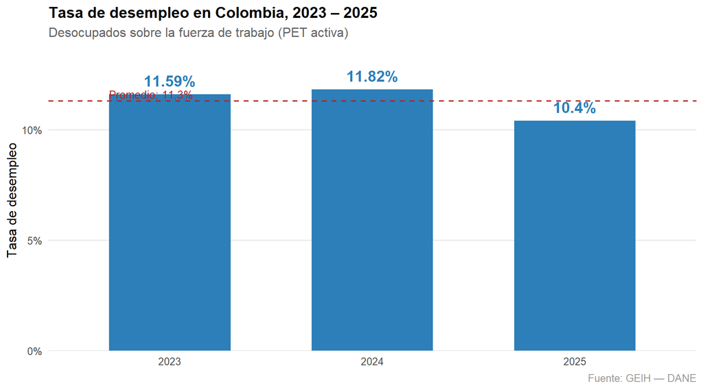

```r
ggplot(tasa_desempleo_anual, aes(x = factor(ANIO), y = tasa_desempleo)) +
  geom_col(fill = "#2C7FB8", width = 0.6) +
  geom_text(aes(label = paste0(tasa_desempleo, "%")),
            vjust = -0.7, size = 5, fontface = "bold", color = "#2C7FB8") +
  geom_hline(yintercept = tasa_global, linetype = "dashed",
             color = "firebrick", linewidth = 0.7) +
  annotate("text",
           x = 0.7, y = tasa_global + 0.3,
           label = paste0("Promedio: ", tasa_global, "%"),
           color = "firebrick", size = 3.5, hjust = 0) +
  scale_y_continuous(
    limits = c(0, max(tasa_desempleo_anual$tasa_desempleo) * 1.15),
    expand = c(0, 0),
    labels = function(x) paste0(x, "%")
  ) +
  labs(
    x        = NULL,
    y        = "Tasa de desempleo",
    title    = "Tasa de desempleo en Colombia, 2023 – 2025",
    subtitle = "Desocupados sobre la fuerza de trabajo (PET activa)",
    caption  = "Fuente: GEIH — DANE"
  ) +
  theme_minimal(base_size = 12) +
  theme(
    plot.title         = element_text(face = "bold", size = 14),
    plot.subtitle      = element_text(color = "gray40",
                                      margin = ggplot2::margin(b = 10)),
    plot.caption       = element_text(color = "gray60", hjust = 1),
    panel.grid.major.x = element_blank(),
    panel.grid.minor   = element_blank()
  )
```

## 5.3 Paso 3 — Seleccionar variables relevantes

En lugar de modelar con las 546 columnas crudas, escogemos un subconjunto justificado teóricamente. Criterios:

```r
# si df_modelo ya está cargado, saltamos.
if (df_modelo_listo) {
  cat("df_modelo ya cargado, se omite este paso\n")
} else {

vars_modelo <- c(
  # -- Llaves e identificacion --
  "PERIODO", "ANIO", "MES_NUM", "FEX_C18", "DPTO", "CLASE",
  "DIRECTORIO", "SECUENCIA_P", "ORDEN", "HOGAR",
  # (Nota: AREA no se incluye — es redundante con CLASE y tiene 27% NA)

  # -- Demograficas --
  "P3271", "P6040", "P6050", "P6080", "P6070",
  "P3038", "P3039",
  "P2057", "P2059", "P2061",   # Autorreconocimiento campesino (actual, pasado, comunidad)
  "P6083", "P6081", "P6071",   # Madre, padre y conyuge residen en el hogar

  # -- Educacion --
  "P3042", "P3042S1", "P3043", "P6170", "P6160",

  # -- Salud y discapacidad --
  "P6090", "P6100",
  "P1906S1", "P1906S3", "P1906S4",
  "P1906S5", "P1906S6", "P1906S7", "P1906S8",

  # -- Hogar y vivienda --
  "P6008", "P5090", "P4000", "P4010", "P4020",
  "P4030S1", "P4030S1A1",
  "P4030S2", "P4030S3", "P4030S4", "P4030S5",   # NBI: gas, alcantarillado, basuras, acueducto
  "P5000", "P5010", "P5020", "P5050", "P5080",

  # -- Inclusion financiera del hogar (multi-respuesta P5222*) --
  "P5222S1",                   # Cuenta corriente
  "P5222S2",                   # Cuenta de ahorros
  "P5222S7",                   # Tarjeta de credito
  "P5222S11",                  # Plataforma movil (nuevo 2025: Nequi, Daviplata, etc.)
  "P5222S9",                   # Ningun producto financiero

  # -- Fuerza de trabajo (aplica a toda la PET) --
  "P6240",                     # Actividad principal semana pasada
  "P6280",                     # Hizo diligencias para buscar trabajo
  "P6310",                     # Razon por la que no busco aunque desea trabajar
  "P6320",                     # Trabajo al menos 2 semanas en ultimos 12 meses
  "P6340",                     # Busco trabajo en ultimos 12 meses
  "P6351",                     # Disponibilidad la semana pasada

  # -- Trabajo (solo aplica a ocupados) --
  "P6430",                     # Posicion ocupacional (formal/informal)

  # -- No ocupados (solo desocupados / inactivos) --
  "DSI", "DSCY",               # Indicador desocupado sin / con experiencia
  "P7250",                     # Semanas buscando trabajo (duracion del desempleo)
  "P7430",                     # Ha trabajado alguna vez
  "P7440S1",                   # Meses desde el ultimo trabajo
  "P7450",                     # Razon por la que dejo el ultimo trabajo
  "P7350",                     # Posicion ocupacional en el ultimo trabajo
  "P744",                      # Disponibilidad la semana pasada (no ocupados)
  "P9460",                     # Recibe subsidio de desempleo

  # -- Vulnerabilidad / transferencias (otros ingresos) --
  "P7510S2",                   # Recibe remesas del exterior
  "P1661S1",                   # Familias en Accion
  "P1661S2",                   # Jovenes en Accion
  "P1661S3",                   # Colombia Mayor

  # -- Migracion --
  "P3373", "P3376", "P3383", "P3385",
  "P3386",                     # Motivo del cambio de residencia (12 meses)

  # -- Variables objetivo --
  "desempleado", "estado_laboral"
)

# `intersect` se queda con las que existen; `setdiff` revela las ausentes.
vars_disponibles <- intersect(vars_modelo, names(df_pet))
vars_ausentes    <- setdiff(vars_modelo, names(df_pet))

if (length(vars_ausentes) > 0) {
  cat("Atencion: Variables solicitadas pero no encontradas:\n")
  print(vars_ausentes)
}

df_modelo <- df_pet %>% dplyr::select(all_of(vars_disponibles))

cat("\nDimensiones del dataset de modelado:\n")
cat("  Filas    :", format(nrow(df_modelo), big.mark = ","), "\n")
cat("  Columnas :", ncol(df_modelo), "\n")

# -- Liberar memoria: df_pet ya no se usa ---------------------
rm(df_pet)
gc()
}
```

```
##
## Dimensiones del dataset de modelado:
##   Filas    : 1,932,781
##   Columnas : 85
```

```
##              used    (Mb) gc trigger    (Mb)   max used    (Mb)
## Ncells    1714213    91.6    4195729   224.1    8194782   437.7
## Vcells 1528403318 11660.8 3855754308 29417.1 3212515899 24509.6
```

## 5.4 Paso 4 — Diagnóstico de faltantes en el subset

Tras filtrar a PET, construir la variable objetivo y seleccionar las variables relevantes, repetimos el conteo de faltantes sobre el subset reducido. Esto nos permite confirmar que la estrategia selectiva funcionó y decidir el tratamiento específico que recibirá cada columna restante.

```r
if (df_modelo_listo) {
  cat("df_modelo ya cargado, se omite este paso\n")
} else {
  # % de faltantes sobre el subset reducido (clasifica el tratamiento).
  falt_subset <- tibble(
    columna  = names(df_modelo),
    pct_falt = round(sapply(df_modelo, pct_faltante), 2)
  ) %>%
    arrange(desc(pct_falt))

  print(falt_subset, n = Inf)
}
```

```
## # A tibble: 85 × 2
##    columna        pct_falt
##    <chr>             <dbl>
##  1 P1661S2           99.6
##  2 P6340             99.0
##  3 P5222S1           98.9
##  4 P6320             98.5
##  5 P1661S1           98.4
##  6 P3386             97.4
##  7 P744              96.7
##  8 P1661S3           96.4
##  9 P6310             96.2
## 10 DSCY              95.4
## 11 DSI               93.3
## 12 P7250             93.3
```

[output cut: 73 more lines]

## 5.5 Paso 5 — Tratamiento de faltantes según porcentaje

El diagnóstico del subset detecta variables con faltantes que provienen de dos fuentes distintas: **NA por diseño del cuestionario** (variables que solo se preguntan a un subgrupo, como `P5222*`, `P6071`, `P7250`, `P7430`, `P1661S*`, etc.) y **NA por no-respuesta real**.

El grueso lo resolvemos en el **pre-tratamiento** del paso anterior (NA estructural → `0` para binarias o `99` para categóricas). Las variables restantes — con NA por no-respuesta real — entran al pipeline siguiente, donde aplicamos dos estrategias diferenciadas según el porcentaje y la naturaleza de cada variable:

- **< 10 % faltantes** → imputación simple (mediana para numéricas, moda para categóricas).
- **10 – 50 % faltantes** → recodificación como categoría `"No informa"` (preserva la no-respuesta como información útil).
- **Variables sensibles de identidad o nivel socioeconómico** → siempre recodificación, aunque tengan pocos faltantes.

### 5.5.1 Criterio adicional: variables sensibles

Tres variables del subset, aunque tengan menos del 10 % de faltantes, no se imputan porque hacerlo introduciría un sesgo metodológico:

| Variable | % NA | Razón por la que NO se imputa |
| --- | --- | --- |
| `P3038` | 6.23 | **Orientación sexual**. La moda es “heterosexual” (>95 %). Imputar con moda eliminaría a las minorías LGBTI, justo el grupo cuya vulnerabilidad nos interesa. |
| `P3039` | 6.23 | **Identidad de género**. Mismo problema: imputar con la moda (“cisgénero”) borra a las personas trans. |
| `P4030S1A1` | 3.54 | **Estrato socioeconómico**. Variable ordinal con peso económico claro; asignar la moda (estrato 2) inventa nivel socioeconómico al 3.5 % sin información. |

### 5.5.2 Variables a imputar

Todas las variables con < 10 % de faltantes (que no estén marcadas como sensibles) reciben imputación simple. Las representativas son atributos del hogar o información objetiva del entorno:

| Variable | % NA | Tipo | Método | Justificación |
| --- | --- | --- | --- | --- |
| `P6100` | 3.95 | Categórica | Moda | Régimen de salud — distribución bien repartida. |
| `P5080` | 3.76 | Categórica | Moda | Combustible para cocinar — atributo del hogar. |
| `P3376` | 3.31 | Binaria | Moda | ¿Vivió en exterior? — la inmensa mayoría responde “No”. |
| `P6008` | 3.00 | Numérica | Mediana | Personas en el hogar — mediana estable (~3). |
| `P5090` | 3.00 | Categórica | Moda | Tenencia de vivienda. |
| `P4010` | 3.00 | Categórica | Moda | Material de paredes. |
| `P4020` | 3.00 | Categórica | Moda | Material de pisos. |
| `P4030S1` | 3.00 | Binaria | Moda | Energía eléctrica — >98 % la tiene. |
| `P4030S2` | ~3 | Binaria | Moda | Gas natural — parte del score NBI. |
| `P4030S3` | ~3 | Binaria | Moda | Alcantarillado — parte del score NBI. |
| `P4030S4` | ~3 | Binaria | Moda | Recolección de basuras — parte del score NBI. |
| `P4030S5` | ~3 | Binaria | Moda | Acueducto — parte del score NBI. |
| `P5000` | 3.00 | Numérica | Mediana | Cuartos disponibles. |
| `P5010` | 3.00 | Numérica | Mediana | Cuartos para dormir — usado para calcular hacinamiento. |
| `P5020` | 3.00 | Categórica | Moda | Servicio sanitario. |
| `P5050` | 3.00 | Categórica | Moda | Fuente de agua. |
| `P3383` | 1.84 | Categórica | Moda | Zona urbana/rural hace 5 años. |
| `P3385` | 0.35 | Categórica | Moda | Zona urbana/rural hace 12 meses. |

**Criterios comunes que justifican imputar estas variables:**

1. **Faltantes bajos (<10 %)** → efecto marginal sobre la distribución.
2. **No son variables de identidad personal** → sin riesgo de borrar minorías vulnerables.
3. **Atributos del hogar u objetivos del entorno** → la no-respuesta suele ser administrativa, no un sesgo sistemático.

### 5.5.3 Variables a recodificar

Las variables con faltantes altos (10–50 %) y las marcadas como sensibles reciben `"No informa"` (categóricas) o `99` (numéricas, convención DANE) para preservar la no-respuesta como categoría informativa:

| Variable | % NA | Motivo de recodificación |
| --- | --- | --- |
| `P6430` | 45.80 | Faltantes altos: posición ocupacional, solo aplica a ocupados. |
| `P3043` | 36.93 | Faltantes altos: solo aplica a quienes obtuvieron título educativo. |
| `P4000` | 34.10 | Faltantes altos: tipo de vivienda no siempre se captura. |
| `P2059` | 31.90 | Faltantes altos: autorreconocimiento campesino pasado, pregunta condicionada. |
| `P3038` | 6.23 | **Sensible**: imputar borraría minorías LGBTI. |
| `P3039` | 6.23 | **Sensible**: imputar borraría personas trans. |
| `P4030S1A1` | 3.54 | **Sensible**: estrato ordinal con peso económico. |

### 5.5.4 Justificación general del enfoque

La imputación por **mediana** (numéricas) y **moda** (categóricas) es la estrategia más conservadora y reproducible cuando los faltantes son pocos. No introduce supuestos fuertes (a diferencia de KNN o regresión múltiple) y mantiene la base operable para los modelos.

Las variables con faltantes altos o de identidad personal se **recodifican** porque el hecho mismo de no responder puede ser un predictor relevante del desempleo (por ejemplo, no informar la tenencia de cuenta de ahorros puede correlacionar con informalidad laboral).

### 5.5.5 Pre-tratamiento: variables con NA estructural

Buena parte de las variables tienen NA por **diseño del cuestionario**: solo se pregunta a un subgrupo (ocupados, desocupados, quienes tienen pareja, etc.). Para estas, el `NA` significa “no aplica”, no “no respondió”. Las tratamos manualmente antes del pipeline general, distinguiendo dos casos:

- **Binarias / multi-respuesta** (1 = Sí; el resto = “no aplica” o “no”): `NA` → `0`. Incluye productos financieros (`P5222S*`), cónyuge en hogar (`P6071`), indicadores de fuerza de trabajo (`DSI`, `DSCY`), búsqueda de empleo (`P6280`, `P6320`, `P6340`, `P6351`, `P744`), historial laboral (`P7430`), subsidio de desempleo (`P9460`), remesas y transferencias (`P7510S2`, `P1661S1-S3`) y contadores como semanas buscando (`P7250`) o meses desde el último empleo (`P7440S1`).
- **Categóricas con códigos múltiples** (actividad principal, razón de no búsqueda, razón de salida, posición ocupacional anterior, motivo de migración): `NA` → `99` (convención DANE para “No aplica / No informa”). Después se recodifican a categorías legibles en el paso siguiente.

```r
if (df_modelo_listo) {
  cat("df_modelo ya cargado, se omite este paso\n")
} else {

# Binarias / multi-respuesta: NA = no aplica = 0, valores != 1 = 0, 1 = 1
vars_na_cero <- c(
  # Productos financieros (multi-respuesta P5222*)
  "P5222S1", "P5222S2", "P5222S7", "P5222S11", "P5222S9",
  # Composicion familiar
  "P6071",
  # Indicadores de fuerza de trabajo (solo desocupados)
  "DSI", "DSCY",
  # Busqueda de empleo (binarias)
  "P6280", "P6320", "P6340", "P6351", "P744",
  # Historial laboral y subsidio
  "P7430", "P9460",
  # Vulnerabilidad / transferencias
  "P7510S2", "P1661S1", "P1661S2", "P1661S3"
)

df_modelo <- df_modelo %>%
  mutate(across(
    all_of(intersect(vars_na_cero, names(df_modelo))),
    ~ ifelse(is.na(.x) | .x != 1, 0L, 1L)
  ))

# CONTADORES: NA = no aplica = 0, pero PRESERVAR el valor original.
# IMPORTANTE: estas son variables continuas (número de semanas, meses).
# NO deben tratarse como binarias 0/1 — el valor real importa.
vars_contadores <- c(
  "P7250",    # Semanas buscando trabajo (continuo, hasta ~52)
  "P7440S1"   # Meses desde el ultimo trabajo (continuo)
)

df_modelo <- df_modelo %>%
  mutate(across(
    all_of(intersect(vars_contadores, names(df_modelo))),
    ~ ifelse(is.na(.x), 0L, as.integer(.x))
  ))

# Categoricas estructurales: NA = no aplica = 99 (DANE)
vars_na_99 <- c(
  "P6240",          # Actividad principal semana pasada
  "P6310",          # Razon por la que no busco
  "P7450", "P7350", # Razon / posicion en ultimo trabajo
  "P3386"           # Motivo del cambio de residencia
)

df_modelo <- df_modelo %>%
  mutate(across(
    all_of(intersect(vars_na_99, names(df_modelo))),
    ~ ifelse(is.na(.x), 99L, as.integer(.x))
  ))

# Verificacion rapida
cat("Pre-tratamiento aplicado a", length(vars_na_cero) + length(vars_na_99),
    "variables.\n")
cat("Resumen de las binarias (% con valor 1):\n")
df_modelo %>%
  summarise(across(all_of(intersect(vars_na_cero, names(df_modelo))),
                   ~ round(mean(.x == 1) * 100, 2))) %>%
  pivot_longer(everything(), names_to = "variable", values_to = "pct_si") %>%
  arrange(desc(pct_si)) %>%
  print(n = Inf)
}
```

```
## Pre-tratamiento aplicado a 24 variables.
## Resumen de las binarias (% con valor 1):
## # A tibble: 19 × 2
##    variable pct_si
##    <chr>     <dbl>
##  1 P5222S2   63.1
##  2 P6071     45.6
##  3 P7430     25.3
##  4 P5222S9   25.2
##  5 P5222S11  15.8
##  6 P5222S7    8.84
##  7 P6351      6.91
##  8 P6280      6.72
##  9 DSI        6.68
## 10 P1661S3    3.59
## 11 DSCY       2.98
## 12 P744       1.84
## 13 P1661S1    1.56
## 14 P5222S1    1.13
## 15 P7510S2    0.99
## 16 P6320      0.51
## 17 P1661S2    0.39
## 18 P6340      0.2
## 19 P9460      0.06
```